# Data Analysis of the gapminder dataset

05/09/2019

## Introduction

Here we present the results of the analysis of the gapminder dataset.

The gapminder dataset contains data on life expectancy, GDP per capita and population by country.

More information can be found at http://www.gapminder.org/data/.

## General Analysis

The dataset contains `1704` rows and `6` columns.

In line with the description of the dataset, the columns are:

```
[1] "country"
[2] "continent"
[3] "year"
[4] "lifeExp"
[5] "pop"
[6] "gdpPercap"
```

The number of unique countries in the dataset is `142`.

Observations are collected over the years:

```
 [1] 1952 1957 1962 1967 1972 1977 1982 1987 1992 1997 2002 2007
```

## Analysis by variable

Continuing our analysis, we will focus on the variables:

- `Population`
- `Life Expectancy`
- `GDP per capita`

## Population

China is the country with the largest population, followed by India.

| country | continent | year | pop |
| --- | --- | --- | --- |
| China | Asia | 2007 | 1318683096 |

| country | continent | year | pop |
| --- | --- | --- | --- |
| India | Asia | 2007 | 1110396331 |

## Population

The country with the smallest population is Sao Tome and Principe.

| country | continent | year | pop |
| --- | --- | --- | --- |
| Sao Tome and Principe | Africa | 1952 | 60011 |

Sao Tome and Principe is also the country with the smallest population in 2007.

| country | continent | year | pop |
| --- | --- | --- | --- |
| Sao Tome and Principe | Africa | 2007 | 199579 |

## Population

Increasing trend over the years.

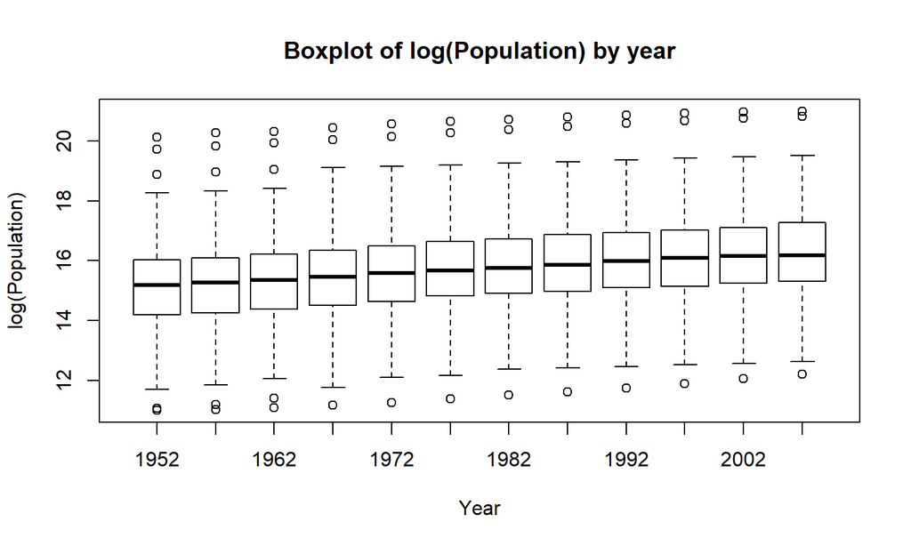

## Life expectancy

- Highest: Japan (2007)
- Lowest Rwanda (1992)

| country | continent | year | lifeExp | pop | gdpPercap |
| --- | --- | --- | --- | --- | --- |
| Japan | Asia | 2007 | 82.603 | 127467972 | 31656.07 |

| country | continent | year | lifeExp | pop | gdpPercap |
| --- | --- | --- | --- | --- | --- |
| Rwanda | Africa | 1992 | 23.599 | 7290203 | 737.0686 |

## Life expectancy

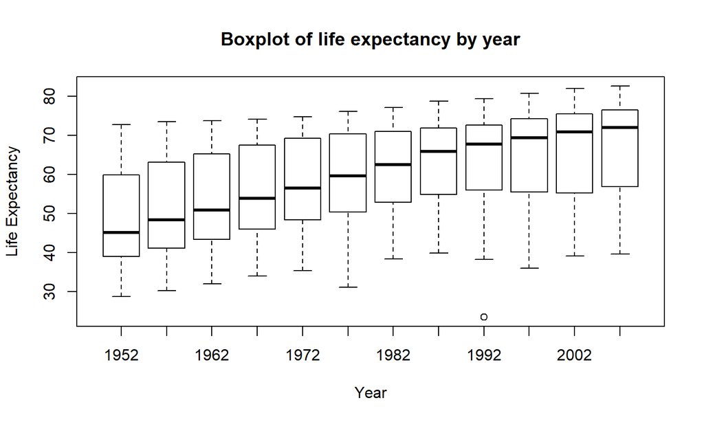

## GDP per capita

- Richest country Kuwait (1957), GDP per capita:`113523` US$.
- Poorest country Congo (2002), GDP per capita `241` US$.

GDP per capita has increased over the years.

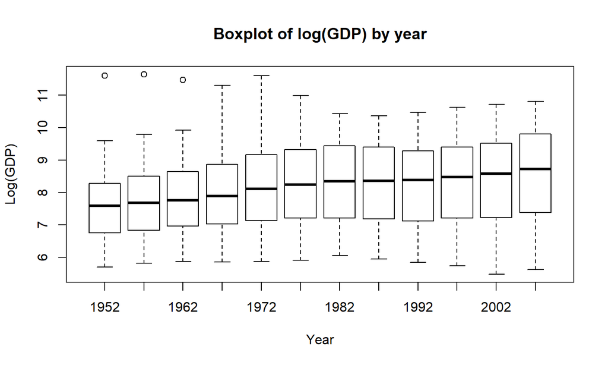

## Conclusion

### Gapminder Dataset

- Life expectancy, GDP per capita and population have increased over the years.
- Countries with highest/lowest GDP per capita are not also the countries with highest/lowest life expectancy.
  - Life expectancy is determined also by other factors than a country’s GDP.